# Atlantic PATH IBD analysis

## DADA2

```bash
mkdir dada2_out
qiime dada2 denoise-paired \
  --i-demultiplexed-seqs trimmed_reads.qza \
  --p-trunc-len-f 260 \
  --p-trunc-len-r 160 \
  --p-max-ee-f 2 \
  --p-max-ee-r 2 \
  --p-n-threads 8 \
  --o-table dada2_out/table.qza \
  --o-representative-sequences dada2_out/representative_sequences.qza \
  --o-denoising-stats dada2_out/stats.qza

qiime metadata tabulate \
  --m-input-file dada2_out/stats.qza \
  --o-visualization stats_dada2_out.qzv

qiime feature-table summarize \
  --i-table dada2_out/table.qza  \
  --o-visualization summary_dada2_out.qzv
```

## Merge tables

```bash
qiime feature-table merge \
  --i-tables Future_IBD_samples/previous_seqd_processing/dada2_out/table.qza \
  --i-tables Future_IBD_samples/Run376_processing/dada2_out/table.qza \
  --i-tables Future_IBD_samples/Run377_processing/dada2_out/table.qza \
  --i-tables other_IBD/Plate10102440_processing/dada2_out/table.qza \
  --i-tables other_IBD/redos_processing/dada2_out/table.qza \
  --i-tables other_IBD/Run218_processing/dada2_out/table.qza \
  --i-tables other_IBD/Run223_processing/dada2_out/table.qza \
  --i-tables other_IBD/Run225_processing/dada2_out/table.qza \
  --i-tables other_IBD/Run232_processing/dada2_out/table.qza \
  --o-merged-table merged_table.qza

qiime feature-table merge-seqs \
  --i-data Future_IBD_samples/previous_seqd_processing/dada2_out/representative_sequences.qza \
  --i-data Future_IBD_samples/Run376_processing/dada2_out/representative_sequences.qza \
  --i-data Future_IBD_samples/Run377_processing/dada2_out/representative_sequences.qza \
  --i-data other_IBD/Plate10102440_processing/dada2_out/representative_sequences.qza \
  --i-data other_IBD/redos_processing/dada2_out/representative_sequences.qza \
  --i-data other_IBD/Run218_processing/dada2_out/representative_sequences.qza \
  --i-data other_IBD/Run223_processing/dada2_out/representative_sequences.qza \
  --i-data other_IBD/Run225_processing/dada2_out/representative_sequences.qza \
  --i-data other_IBD/Run232_processing/dada2_out/representative_sequences.qza \
  --o-merged-data merged_representative_sequences.qza
```

## Classify

```bash
qiime feature-classifier classify-sklearn \
  --i-reads merged_representative_sequences.qza \
  --i-classifier /home/shared/taxa_classifiers/qiime2-2020.8_classifiers/silva-138-99-nb-classifier.qza \
  --p-n-jobs 12 \
  --output-dir taxa

qiime tools export \
  --input-path taxa/classification.qza \
  --output-path taxa
```

## Filter features

```bash
qiime feature-table filter-features \
  --i-table merged_table.qza \
  --p-min-frequency 5 \
  --p-min-samples 1 \
  --o-filtered-table table_filtered.qza

qiime feature-table summarize \
  --i-table table_filtered.qza \
  --o-visualization summary_table_filtered.qzv

qiime taxa filter-table \
  --i-table table_filtered.qza \
  --i-taxonomy taxa/classification.qza \
  --p-include d__ \
  --p-exclude mitochondria,chloroplast \
  --o-filtered-table table_filtered_contamination.qza

qiime feature-table summarize \
  --i-table table_filtered_contamination.qza \
  --o-visualization summary_table_filtered_contamination.qzv
```

## Filter

*Not rarefying or removing samples with low numbers of reads*

```bash
qiime feature-table filter-seqs \
  --i-data merged_representative_sequences.qza \
  --i-table table_filtered_contamination.qza \
  --o-filtered-data  representative_sequences_filtered_contamination.qza
```

## Insert sequences into tree

```bash
qiime fragment-insertion sepp \
  --i-representative-sequences representative_sequences_filtered_contamination.qza \
  --i-reference-database /home/robyn/tools/sepp/sepp-refs-silva-128.qza \
  --o-tree insertion_tree.qza \
  --o-placements insertion_placements.qza \
  --p-threads 12
```

## Get rarefaction curves

```bash
qiime diversity alpha-rarefaction \
  --i-table table_filtered_contamination.qza \
  --p-max-depth 131945 \
  --p-steps 20 \
  --p-metrics 'observed_features' \
  --o-visualization rarefaction_curves.qzv
```

Screenshot from the QIIME2 website:

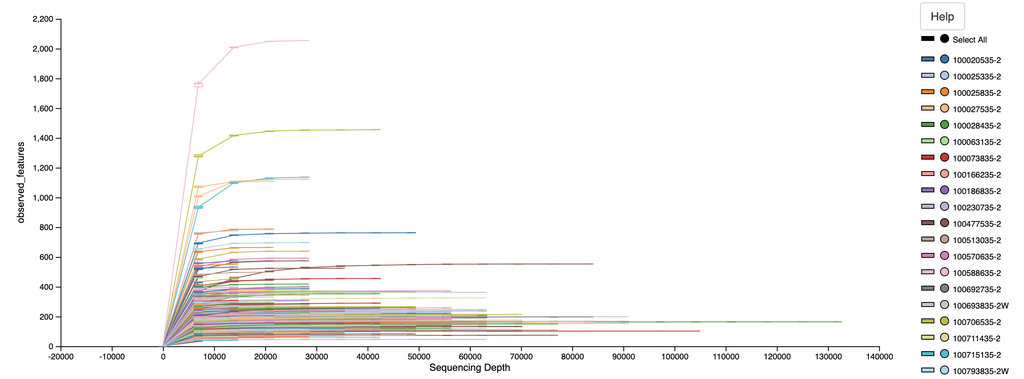

## Export all files

```bash
qiime tools export \
  --input-path representative_sequences_filtered_contamination.qza \
  --output-path exports

sed -i -e '1 s/Feature/#Feature/' -e '1 s/Taxon/taxonomy/' taxa/taxonomy.tsv

qiime tools export \
  --input-path table_filtered_contamination.qza \
  --output-path exports

biom add-metadata \
  -i exports/feature-table.biom \
  -o exports/feature-table_w_tax.biom \
  --observation-metadata-fp taxa/taxonomy.tsv \
  --sc-separated taxonomy

biom convert \
  -i exports/feature-table_w_tax.biom \
  -o exports/feature-table_w_tax.txt \
  --to-tsv \
  --header-key taxonomy

qiime tools export \
  --input-path insertion_tree.qza \
  --output-path exports
```

# Basic analysis

## Sort metadata

Metadata is currently in three different tables: original, baseline and followup. Some of the variable names are the same between these, some are not. I’ve identified which match between them in the variable labels file, and have added a column with a new name for each. Now to add all of the metadata to a single file and check, adding only the data for samples that we actually have.

```python
variable_labels = pd.read_csv('/Users/robynwright/Documents/OneDrive/Langille_Lab_postdoc/AtPATH_IBD/Metadata/sorting/variable_labels.csv', header=0)
baseline_data = pd.read_csv('/Users/robynwright/Documents/OneDrive/Langille_Lab_postdoc/AtPATH_IBD/Metadata/sorting/baseline_data.csv', header=0)
followup_data = pd.read_csv('/Users/robynwright/Documents/OneDrive/Langille_Lab_postdoc/AtPATH_IBD/Metadata/sorting/followup_data.csv', header=0)
original_data = pd.read_csv('/Users/robynwright/Documents/OneDrive/Langille_Lab_postdoc/AtPATH_IBD/Metadata/sorting/original_data.csv', header=0)
label_dict = {}

for row in variable_labels.index.values:
  followup, baseline, original, new = variable_labels.loc[row, ['variable_name_followup', 'variable_name_baseline', 'variable_name_original', 'new_name']].values
  if isinstance(followup, str): label_dict[followup] = new
  if isinstance(baseline, str): label_dict[baseline] = new
  if isinstance(original, str): label_dict[original] = new

new_labels = variable_labels.loc[:, 'new_name'].values
baseline_data.rename(columns=label_dict, inplace=True)
followup_data.rename(columns=label_dict, inplace=True)
original_data.rename(columns=label_dict, inplace=True)
datasets = [baseline_data, followup_data, original_data]

variable_labels['BASELINE_VARIABLES'] = ''
variable_labels['FOLLOWUP_VARIABLES'] = ''
variable_labels['ORIGINAL_VARIABLES'] = ''
dataset_names = ['BASELINE_VARIABLES', 'FOLLOWUP_VARIABLES', 'ORIGINAL_VARIABLES']
variable_labels.set_index('new_name', inplace=True)

for label in new_labels:
  for d in range(len(datasets)):
    data = datasets[d]
    if label not in data.columns:
      variable_labels.loc[label, dataset_names[d]] = 'Not in dataset'
      continue
    all_vals = list(data.loc[:, label])
    all_vals = [str(val) for val in all_vals]
    all_vals = set(all_vals)
    this_variable = ''
    for val in all_vals:
      if this_variable != '': this_variable += ', '+str(val)
      else: this_variable += str(val)
    variable_labels.loc[label, dataset_names[d]] = this_variable

variable_labels.to_csv('/Users/robynwright/Documents/OneDrive/Langille_Lab_postdoc/AtPATH_IBD/Metadata/sorting/sorted_variable_labels.csv')

baseline_data.loc[:, 'DATASET'] = 'baseline'
followup_data.loc[:, 'DATASET'] = 'followup'
original_data.loc[:, 'DATASET'] = 'original'

new_columns = set(['DATASET']+list(new_labels))
count = 0
datasets = [baseline_data, followup_data, original_data]

for data in datasets:
  for col in new_columns:
    if col not in data.columns:
      data[col] = 'NA'
  if count == 0:
    combined_data = data.loc[:, new_columns].set_index('SALIVA')
  else:
    combined_data = pd.concat([combined_data, data.loc[:, new_columns].set_index('SALIVA')])
  count += 1

combined_data.to_csv('/Users/robynwright/Documents/OneDrive/Langille_Lab_postdoc/AtPATH_IBD/Metadata/sorting/sorted_metadata.csv')
```

Get original fastq file names:

```python
import os
import pickle

folders = ['Plate10102440_processing', 'redos_processing', 'Run218_processing', 'Run223_processing', 'Run225_processing', 'Run232_processing']
all_fastq = []
for folder in folders:
  contents = os.listdir(folder)
  for file in contents:
    if 'rawdata' in file:
      fastq = os.listdir(folder+'/'+file)
      all_fastq = all_fastq+fastq

for f in range(len(all_fastq)):
  all_fastq[f] = all_fastq[f].split('_')[0]

all_fastq = list(set(all_fastq))
print(len(all_fastq))

with open('all_file_names.list', 'wb') as f:
    pickle.dump(all_fastq, f)
```

## Import data

Sort data (matching sample names between the feature table and reducing the metadata table to only include samples that are in the feature table):

```python
metadata = pd.read_csv('/Users/robynwright/Documents/OneDrive/Langille_Lab_postdoc/AtPATH_IBD/Metadata/sorting/sorted_metadata.csv', header=0)
```

```python
saliva, duplicates, keeping = [], [], []

metadata['SAMPLE_NAME_FT'] = metadata['SAMPLE_NAME_FT'].astype(str)
for row in metadata.index.values:
  if '.0' in metadata.loc[row, 'SAMPLE_NAME_FT']:
    metadata.loc[row, 'SAMPLE_NAME_FT'] = str(int(float(metadata.loc[row, 'SAMPLE_NAME_FT'])))
metadata = metadata.set_index('SALIVA')
metadata.index = metadata.index.map(str)

for row in list(metadata.index.values):
  if row in saliva: duplicates.append(row)
  else: saliva.append(row)
  if not isinstance(metadata.loc[row, 'GROUP'], str):
    if row != 'sterile-water': keeping.append(row)
  elif 'IBD' in metadata.loc[row, 'GROUP']:
    if row != 'sterile-water': keeping.append(row)

metadata[metadata.loc[:, 'GROUP'] != 'IBD'] = 'IBD'

for dup in duplicates:
  metadata.loc[dup, 'GROUP'] = 'FUTURE_IBD'

ft = pd.read_csv('/Users/robynwright/Documents/OneDrive/Langille_Lab_postdoc/AtPATH_IBD/exports/feature-table_w_tax.txt', index_col=0, header=0, sep='\t')

new_keeping_sample, new_keeping_saliva, not_keeping, md_rename = [], [], {}, {}
columns = list(ft.columns)
split_columns = [col.split('-')[0] for col in columns]
columns = columns

def check_sample(sample_checking, saliva_checking, list_checking, list_checking_split, nk_sample, nk_saliva, not_k, metadata_rename):
  if sample_checking in list_checking:
    nk_sample.append(sample_checking)
    nk_saliva.append(saliva_checking)
  for sam in list_checking:
      if sample_checking == sam.split('-')[0] and sample_checking != sam and '2' not in sam.split('-')[1]:
        nk_sample.append(sam)
        nk_saliva.append(saliva_checking)
        md_rename[saliva_checking] = sam
  else:
    if saliva_checking in not_k:
      if sample_checking not in not_k[saliva_checking]:
        not_k[saliva_checking] = not_k[saliva_checking]+[sample_checking]
    else:
      not_k[saliva_checking] = [sample_checking]
  return nk_sample, nk_saliva, not_k, metadata_rename

for saliva in keeping:
  sample = metadata.loc[saliva, 'SAMPLE_NAME_FT']
  if not isinstance(sample, str):
    if isinstance(sample, float): sample = str(sample)
    else: sample = list(sample)
  if isinstance(sample, str):
    if '.0' in sample: sample = str(int(float(sample)))
    new_keeping_sample, new_keeping_saliva, not_keeping, md_rename = check_sample(sample, saliva, columns, split_columns, new_keeping_sample, new_keeping_saliva, not_keeping, md_rename)
  else:
    for sam in sample:
      sam = str(sam)
      if '.0' in sam: sam = str(int(float(sam)))
      new_keeping_sample, new_keeping_saliva, not_keeping, md_rename = check_sample(sam, saliva, columns, split_columns, new_keeping_sample, new_keeping_saliva, not_keeping, md_rename)
new_keeping_sample, new_keeping_saliva = list(set(new_keeping_sample)), list(set(new_keeping_saliva))

ft_reduced = ft.loc[:, new_keeping_sample+['taxonomy']]
metadata_reduced = metadata.loc[new_keeping_saliva, :]

sample_rename = {}
for sal in md_rename:
  sample_rename[sal] = md_rename[sal].split('-')[0]
ft_reduced = ft_reduced.rename(columns=sample_rename)

# metadata_reduced.to_csv(save_path+'metadata_reduced.csv')
# ft_reduced.to_csv(save_path+'ft_1_reduced_metadata.csv')
```

## Summarise by metadata variables

Show all samples, samples grouped by healthy/IBD/future IBD  
Groups:  
- IBD  
- FUTURE_IBD

```python
metadata_fn = save_path+'metadata_reduced.csv'
ft_fn = save_path+'ft_1_reduced_metadata.csv'
```

```python
metadata = pd.read_csv(metadata_fn, index_col=0, header=0)
ft = pd.read_csv(ft_fn, index_col=0, header=0).drop('taxonomy', axis=1)
metadata_group = metadata.set_index('GROUP')
```

### Gender

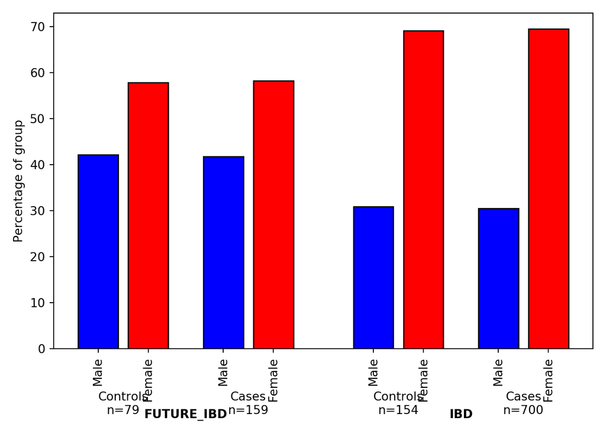

```python
def plot_two_category_discrete(category_dict, category, md, percent=False):
  groups = list(set(md.index.values))
  count = 0
  plot, x, names, colors = [], [1, 2, 3.5, 4.5, 6.5, 7.5, 9, 10], [], ['b', 'r', 'b', 'r', 'b', 'r', 'b', 'r']
  labels = ['Controls\nn=', 'Cases\nn=', 'Controls\nn=', 'Cases\nn=']
  for group in groups:
    md_group = pd.DataFrame(md.loc[group, [category, 'CASE_CONTROL']]).reset_index()
    g1_case, g1_control, g2_case, g2_control = 0, 0, 0, 0
    cats = [cat for cat in category_dict]
    for row in md_group.index.values:
      if md_group.loc[row, 'CASE_CONTROL'] == 0 and md_group.loc[row, category] == cats[0]:
        g1_control += 1
      elif md_group.loc[row, 'CASE_CONTROL'] == 1 and md_group.loc[row, category] == cats[0]:
        g1_case += 1
      elif md_group.loc[row, 'CASE_CONTROL'] == 0 and md_group.loc[row, category] == cats[1]:
        g2_control += 1
      elif md_group.loc[row, 'CASE_CONTROL'] == 1 and md_group.loc[row, category] == cats[1]:
        g2_case += 1
    if count == 0:
      labels[0] += str(g1_case+g2_case)
      labels[1] += str(g1_control+g2_control)
    elif count == 1:
      labels[2] += str(g1_case+g2_case)
      labels[3] += str(g1_control+g2_control)
    count += 1
    if percent:
      perc_g1_case, perc_g1_control, perc_g2_case, perc_g2_control = (g1_case/(g1_case+g2_case))*100, (g1_control/(g1_control+g2_control))*100, (g2_case/(g1_case+g2_case))*100, (g2_control/(g1_control+g2_control))*100
      g1_case, g1_control, g2_case, g2_control = perc_g1_case, perc_g1_control, perc_g2_case, perc_g2_control
    plot = plot+[g1_control, g2_control, g1_case, g2_case]
    names = names+[category_dict[cats[0]], category_dict[cats[1]], category_dict[cats[0]], category_dict[cats[1]]]
  ax1 = plt.subplot(111)
  ax1.bar(x, plot, color=colors, edgecolor='k')
  plt.xticks(x, names, rotation=90)
  if percent:
    ax1.set_ylabel('Percentage of group')
  else:
    ax1.set_ylabel('Number of participants')
  text = [1.5, 4, 7, 9.5]
  for a in range(len(text)):
    ax1.text(text[a], -12, labels[a], ha='center', va='center')
  text = [2.75, 8.25]
  for g in range(len(groups)):
    ax1.text(text[g], -15, groups[g], ha='center', fontweight='bold')
  return

plot_two_category_discrete({1:'Male', 2:'Female'}, 'SDC_GENDER', metadata_group, percent=True)
plt.tight_layout()
plt.show()
```

### Age

```python
def adjacent_values(vals, q1, q3):
    upper_adjacent_value = q3 + (q3 - q1) * 1.5
    upper_adjacent_value = np.clip(upper_adjacent_value, q3, vals[-1])

    lower_adjacent_value = q1 - (q3 - q1) * 1.5
    lower_adjacent_value = np.clip(lower_adjacent_value, vals[0], q1)
    return lower_adjacent_value, upper_adjacent_value

def add_lines(dt, num, ax):
  quartile1, medians, quartile3 = np.percentile(dt, [25, 50, 75])
  whiskers = adjacent_values(dt, quartile1, quartile3)
  whiskersMin, whiskersMax = whiskers[0], whiskers[1]
  inds = np.arange(num, num + 1)

  ax.scatter(inds, medians, marker='o', color='white', s=30, zorder=3)
  ax.vlines(inds, quartile1, quartile3, color='k', linestyle='-', lw=5)
  ax.vlines(inds, whiskersMin, whiskersMax, color='k', linestyle='-', lw=1)
  return

def plot_two_category_continuous(category, md, ax=False):
  groups = list(set(md.index.values))
  x, names, colors = [1, 2, 3, 4], [], ['#CB4335', '#F1C40F', '#CB4335', '#F1C40F']
  labels = ['Controls\nn=', 'Cases\nn=', 'Controls\nn=', 'Cases\nn=']
  data = []
  count = 0
  for group in groups:
    md_group = pd.DataFrame(md.loc[group, [category, 'CASE_CONTROL']]).reset_index()
    case, control = [], []
    for row in md_group.index.values:
      if md_group.loc[row, 'CASE_CONTROL'] == 0:
        control.append(md_group.loc[row, category])
      elif md_group.loc[row, 'CASE_CONTROL'] == 1:
        case.append(md_group.loc[row, category])
    if count == 0:
      labels[0] = labels[0]+str(len(control))
      labels[1] = labels[1]+str(len(case))
    else:
      labels[2] = labels[2]+str(len(control))
      labels[3] = labels[3]+str(len(case))
    count += 1
    data.append(control)
    data.append(case)
  if ax == False:
    ax = plt.subplot(111)
  parts = ax.violinplot(data, showmeans=False, showmedians=False, showextrema=False)
  count = 0
  for pc in parts['bodies']:
    pc.set_facecolor(colors[count])
    pc.set_edgecolor('black')
    pc.set_alpha(1)
    count += 1
  for a in range(len(data)):
    add_lines(data[a], a+1, ax)
  plt.sca(ax)
  plt.xticks(x, labels)
  text = [0.225, 0.775]
  for g in range(len(groups)):
    ax.text(text[g], -0.15, groups[g], ha='center', fontweight='bold', transform=ax.transAxes)
  return

metadata_group = metadata_group.reset_index()
for row in metadata_group.index.values:
  if isinstance(metadata_group.loc[row, 'SDC_AGE_CALC'], float):
    age = metadata_group.loc[row, 'SDC_AGE_CALC']
    if np.isnan(age):
      dob = int(metadata_group.loc[row, 'SDC_DOB'])
      qx = int(metadata_group.loc[row, 'ADM_QX_COMPLETION'].split('/')[-1])
      age = qx-dob
      metadata_group.loc[row, 'SDC_AGE_CALC'] = age
metadata_group = metadata_group.set_index('GROUP')

plot_two_category_continuous('SDC_AGE_CALC', metadata_group)
```

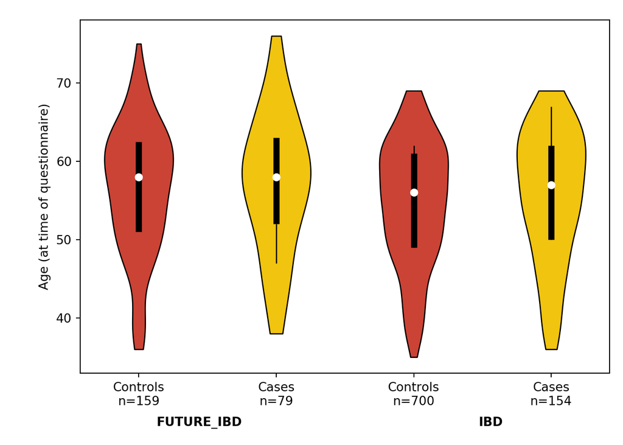

```python
plt.ylabel('Age (at time of questionnaire)')
plt.tight_layout()
plt.show()
```

### Number of reads

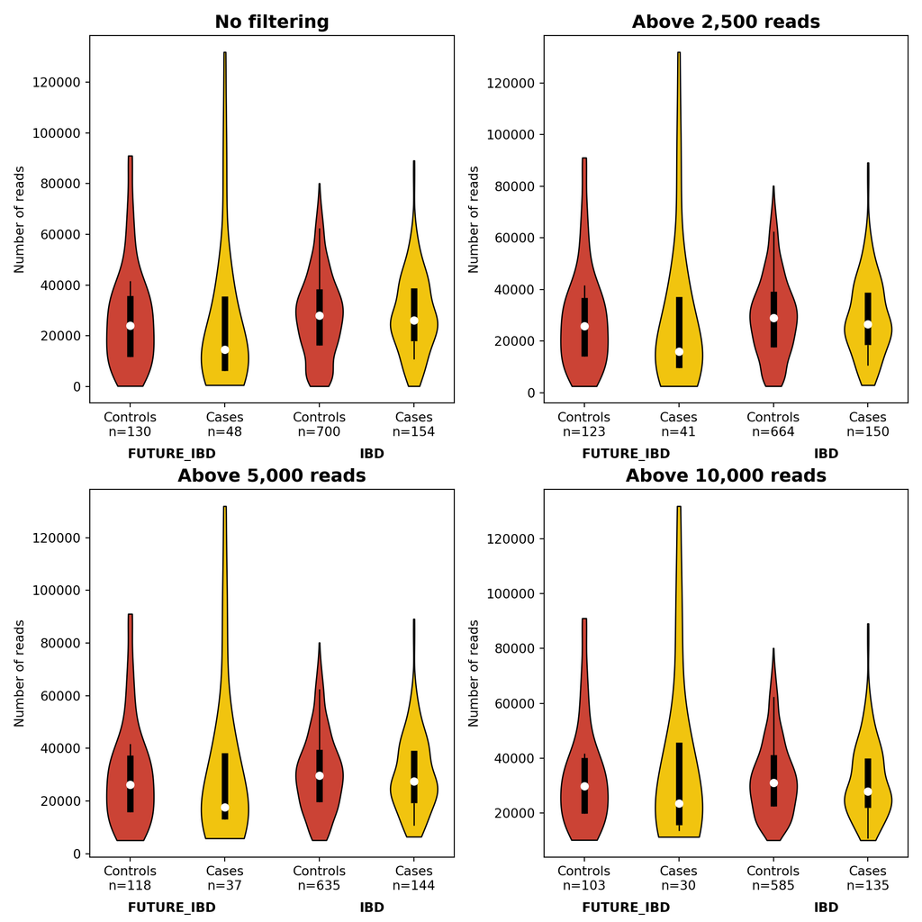

```python
filtering = [0, 2500, 5000, 10000]
#print(metadata_group.loc[:, 'SAMPLE_NAME_FT'])
reads = ft.sum(axis=0)
groups, case_control = {}, {}
metadata = metadata.reset_index()
for row in metadata.index.values:
  sn = metadata.loc[row, 'SAMPLE_NAME_FT']
  group = metadata.loc[row, 'GROUP']
  cc = metadata.loc[row, 'CASE_CONTROL']
  groups[sn] = group
  case_control[sn] = cc
metadata = metadata.set_index('SALIVA')

plt.figure(figsize=(10,10))
axis = [plt.subplot(221), plt.subplot(222), plt.subplot(223), plt.subplot(224)]
titles = ['No filtering', 'Above 2,500 reads', 'Above 5,000 reads', 'Above 10,000 reads']
for a in range(len(axis)):
  reads_keeping = reads >= filtering[a]
  ft_reduced = ft.loc[:, reads_keeping]
  dropping = list(ft_reduced.index.values)
  ft_reduced = ft_reduced.transpose()
  ft_reduced['Reads'] = ft_reduced.sum(axis=1)
  ft_reduced.drop(dropping, axis=1, inplace=True)
  ft_reduced['GROUP'] = ''
  ft_reduced['CASE_CONTROL'] = ''
  for row in ft_reduced.index.values:
    try:
      ft_reduced.loc[row, 'GROUP'] = groups[row]
      ft_reduced.loc[row, 'CASE_CONTROL'] = case_control[row]
    except:
      ft_reduced.loc[row, 'GROUP'] = groups[row.split('-')[0]]
      ft_reduced.loc[row, 'CASE_CONTROL'] = case_control[row.split('-')[0]]
  ft_reduced = ft_reduced.set_index('GROUP')
  plot_two_category_continuous('Reads', ft_reduced, ax=axis[a])
  axis[a].set_ylabel('Number of reads')
  axis[a].set_title(titles[a], fontsize=14, fontweight='bold')

plt.tight_layout()
plt.show()
```

### Richness

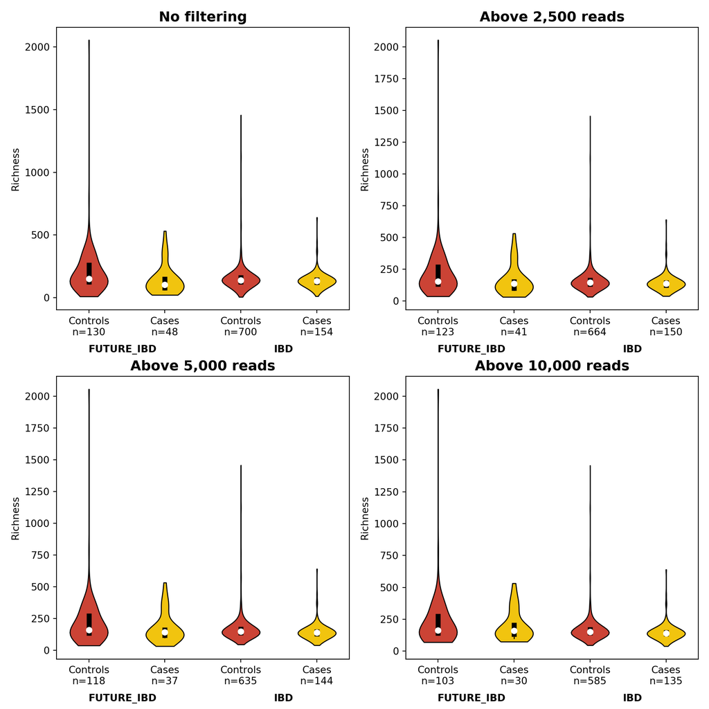

```python
def get_diversity(diversity, sample):
    '''
    function to calculate a range of different diversity metrics
    It takes as input:
        - diversity (the name of the diversity metric we want, can be 'Simpsons', 'Shannon', 'Richness', 'Evenness', 'Maximum' (Maximum is not a diversity metric, the function will just return the maximum abundance value given in sample)
        - sample (a list of abundance values that should correspond to one sample)
    Returns:
        - The diversity index for the individual sample
    '''
    for a in range(len(sample)):
        sample[a] = float(sample[a])
    total = sum(sample)
    if diversity == 'Simpsons':
        for b in range(len(sample)):
            sample[b] = (sample[b]/total)**2
        simpsons = 1-(sum(sample))
        return simpsons
    elif diversity == 'Shannon':
        for b in range(len(sample)):
            sample[b] = (sample[b]/total)
            if sample[b] != 0:
                sample[b] = -(sample[b] * (np.log(sample[b])))
        shannon = sum(sample)
        return shannon
    elif diversity == 'Richness':
        rich = 0
        for b in range(len(sample)):
            if sample[b] != 0:
                rich += 1
        return rich
    elif diversity == 'Evenness':
        for b in range(len(sample)):
            sample[b] = (sample[b]/total)
            if sample[b] != 0:
                sample[b] = -(sample[b] * (np.log(sample[b])))
        shannon = sum(sample)
        rich = 0
        for b in range(len(sample)):
            if sample[b] != 0:
                rich += 1
        even = shannon/(np.log(rich))
        return even
    elif diversity == 'Maximum':
        ma = (max(sample)/total)*100
        return ma
    return

plt.figure(figsize=(10,10))
axis = [plt.subplot(221), plt.subplot(222), plt.subplot(223), plt.subplot(224)]
titles = ['No filtering', 'Above 2,500 reads', 'Above 5,000 reads', 'Above 10,000 reads']
for a in range(len(axis)):
  reads_keeping = reads >= filtering[a]
  ft_reduced = ft.loc[:, reads_keeping]
  dropping = list(ft_reduced.index.values)
  rich = pd.DataFrame(ft_reduced)
  rich[rich > 0] = 1
  ft_reduced = ft_reduced.transpose()
  ft_reduced['Diversity'] = rich.sum(axis=0)
  ft_reduced.drop(dropping, axis=1, inplace=True)
  ft_reduced['GROUP'] = ''
  ft_reduced['CASE_CONTROL'] = ''
  for row in ft_reduced.index.values:
    try:
      ft_reduced.loc[row, 'GROUP'] = groups[row]
      ft_reduced.loc[row, 'CASE_CONTROL'] = case_control[row]
    except:
      ft_reduced.loc[row, 'GROUP'] = groups[row.split('-')[0]]
      ft_reduced.loc[row, 'CASE_CONTROL'] = case_control[row.split('-')[0]]
  ft_reduced = ft_reduced.set_index('GROUP')
  plot_two_category_continuous('Diversity', ft_reduced, ax=axis[a])
  axis[a].set_ylabel('Richness')
  axis[a].set_title(titles[a], fontsize=14, fontweight='bold')

plt.tight_layout()
plt.show()
```

### Shannon

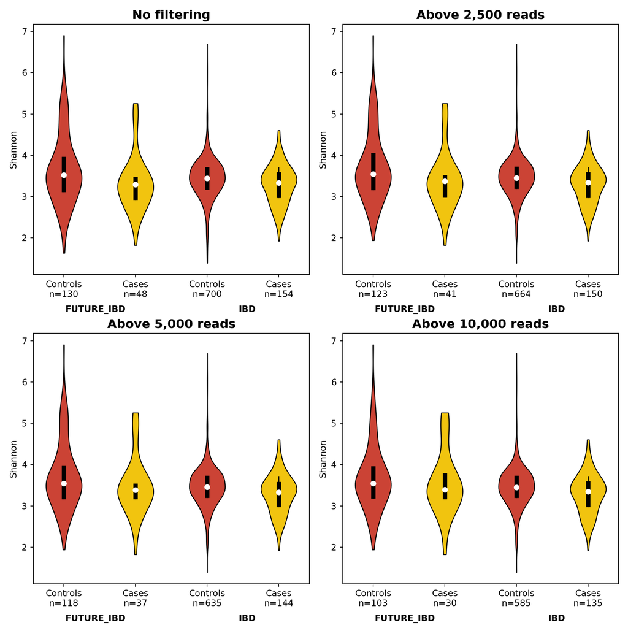

```python
plt.figure(figsize=(10,10))
axis = [plt.subplot(221), plt.subplot(222), plt.subplot(223), plt.subplot(224)]
titles = ['No filtering', 'Above 2,500 reads', 'Above 5,000 reads', 'Above 10,000 reads']
for a in range(len(axis)):
  reads_keeping = reads >= filtering[a]
  ft_reduced = ft.loc[:, reads_keeping]
  dropping = list(ft_reduced.index.values)
  div = []
  for column in ft_reduced.columns:
    sample = list(ft_reduced.loc[:, column])
    div.append(get_diversity('Shannon', sample))
  ft_reduced = ft_reduced.transpose()
  ft_reduced['Diversity'] = div
  ft_reduced.drop(dropping, axis=1, inplace=True)
  ft_reduced['GROUP'] = ''
  ft_reduced['CASE_CONTROL'] = ''
  for row in ft_reduced.index.values:
    try:
      ft_reduced.loc[row, 'GROUP'] = groups[row]
      ft_reduced.loc[row, 'CASE_CONTROL'] = case_control[row]
    except:
      ft_reduced.loc[row, 'GROUP'] = groups[row.split('-')[0]]
      ft_reduced.loc[row, 'CASE_CONTROL'] = case_control[row.split('-')[0]]
  ft_reduced = ft_reduced.set_index('GROUP')
  plot_two_category_continuous('Diversity', ft_reduced, ax=axis[a])
  axis[a].set_ylabel('Shannon')
  axis[a].set_title(titles[a], fontsize=14, fontweight='bold')

plt.tight_layout()
plt.show()
```

### Simpsons

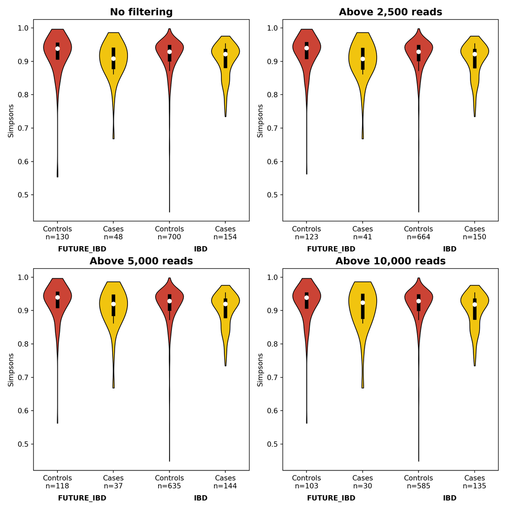

```python
plt.figure(figsize=(10,10))
axis = [plt.subplot(221), plt.subplot(222), plt.subplot(223), plt.subplot(224)]
titles = ['No filtering', 'Above 2,500 reads', 'Above 5,000 reads', 'Above 10,000 reads']
for a in range(len(axis)):
  reads_keeping = reads >= filtering[a]
  ft_reduced = ft.loc[:, reads_keeping]
  dropping = list(ft_reduced.index.values)
  div = []
  for column in ft_reduced.columns:
    sample = list(ft_reduced.loc[:, column])
    div.append(get_diversity('Simpsons', sample))
  ft_reduced = ft_reduced.transpose()
  ft_reduced['Diversity'] = div
  ft_reduced.drop(dropping, axis=1, inplace=True)
  ft_reduced['GROUP'] = ''
  ft_reduced['CASE_CONTROL'] = ''
  for row in ft_reduced.index.values:
    try:
      ft_reduced.loc[row, 'GROUP'] = groups[row]
      ft_reduced.loc[row, 'CASE_CONTROL'] = case_control[row]
    except:
      ft_reduced.loc[row, 'GROUP'] = groups[row.split('-')[0]]
      ft_reduced.loc[row, 'CASE_CONTROL'] = case_control[row.split('-')[0]]
  ft_reduced = ft_reduced.set_index('GROUP')
  plot_two_category_continuous('Diversity', ft_reduced, ax=axis[a])
  axis[a].set_ylabel('Simpsons')
  axis[a].set_title(titles[a], fontsize=14, fontweight='bold')

plt.tight_layout()
plt.show()
```

## Ordination plots

Samples colored/shapes by healthy/IBD/future IBD

### Aitchison distance (Euclidean on CLR)

### PHILR distance

## Taxa bar plots

Just regular bar plots at different levels

## Heat maps

Showing samples ordered by some distance metric and abundance of taxa (genus level?) within the samples

# Differential abundance

ANCOM

# Random Forests

Run for lots of different categories and at different levels

## Healthy/Future IBD/IBD

## Age

## Sex

## Diet

## etc

# Combine differential abundance and random forest